# Dataset structure

## 5. What exists at the end

Annotation availability, not sequencing, decides which galls end up with a usable expression matrix. Three of the six plant references carry gene models; the other three yield alignments and nothing countable.

[figure not shown]

```python
stages = ["genome\nindexed", "gene models\navailable", "count matrix\nproduced"]
matrices = {p.stem.replace("plant_", "") for p in (ROOT / "04_matrix").glob("plant_*.tsv")}

fig, ax = plt.subplots(figsize=(10, 4.2))
blank(ax)
cw, ch, x0, y0 = 0.19, 0.19, 0.34, 0.06
for j, s in enumerate(stages):
    ax.text(x0 + (j + 0.5) * cw, y0 + len(HOSTS) * ch + 0.03, s, ha="center",
            va="bottom", fontsize=8.5, color=INK)
for i, h in enumerate(HOSTS):
    y = y0 + (len(HOSTS) - 1 - i) * ch
    n = (meta.ref_genome == h).sum()
    ax.text(x0 - 0.02, y + ch / 2, f"{pretty(h)}   ({n} gall{'s' * (n != 1)})",
            ha="right", va="center", fontsize=8.5, color=INK if n else INK2)
    flags = [True, h in ANNOT, h in matrices]
    for j, ok in enumerate(flags):
        x = x0 + (j + 0.5) * cw
        ax.scatter(x, y + ch / 2, s=190, marker="o" if ok else "X",
                   color=SERIES[2] if ok else SURFACE,
                   edgecolor=SERIES[2] if ok else GRID, linewidth=1.6, zorder=3)
        if ok and j == 2:
            genes = int(refs.loc[h, "genes"])
            ax.text(x + 0.055, y + ch / 2, f"{genes:,} genes", va="center",
                    fontsize=7.5, color=INK2)
ax.set_title("From genome to countable matrix, per host reference", y=1.10)
note(ax, "Poncirus has no gall of its own any more — those four galls are counted on Citrus sinensis.",
     y=0.0)
save(fig, "26_annotation_coverage"); plt.show()
```

## 6. Library preparation, read back out of the data

The repo documents a wet-lab protocol — 5 µg total RNA, Ribo-Zero rRNA Removal (Bacteria), TruSeq Stranded mRNA with **the polyA-capture step skipped** — but that section of `README.md` describes the 2019 reference paper, not these galls. **How our own libraries were prepared is not recorded anywhere in the repo.** It matters enormously, so the next best thing is to ask the reads.

Gene biotype composition is diagnostic. A library that skipped polyA capture and used a *bacterial* rRNA kit would leave plant rRNA completely undepleted, and plant rRNA would swamp everything. A polyA-selected library does the opposite: rRNA near zero, non-polyadenylated small RNAs absent, protein-coding dominant.

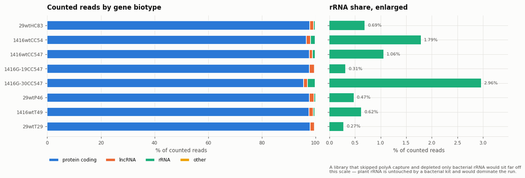

|  | protein_coding | lncRNA | rRNA | other |
| --- | --- | --- | --- | --- |
| 29wtHC83 | 97.906 | 1.357 | 0.687 | 0.050 |
| 1416wtCC54 | 96.607 | 1.556 | 1.790 | 0.048 |
| 1416wtCC547 | 97.781 | 1.076 | 1.059 | 0.084 |
| 1416G-19CC547 | 97.780 | 1.830 | 0.314 | 0.077 |
| 1416G-30CC547 | 95.546 | 1.427 | 2.961 | 0.066 |
| 29wtP46 | 97.762 | 1.763 | 0.472 | 0.002 |
| 1416wtT49 | 97.593 | 1.599 | 0.620 | 0.188 |
| 29wtT29 | 98.090 | 1.485 | 0.273 | 0.151 |

```python
import re

BIOTYPE_GROUPS = ["protein_coding", "lncRNA", "rRNA", "other"]

def biotypes(host):
    out = {}
    for ln in open(ROOT / f"references/plant_host/{host}/{host}.gff3"):
        if "\tgene\t" not in ln:
            continue
        a = ln.split("\t")[8]
        i, b = re.search(r"ID=([^;]+)", a), re.search(r"gene_biotype=([^;\n]+)", a)
        if i and b:
            out[i.group(1)] = b.group(1) if b.group(1) in BIOTYPE_GROUPS else "other"
    return out

comp = {}
for p in sorted((ROOT / "04_matrix").glob("plant_*.tsv")):
    host = p.stem.replace("plant_", "")
    m = pd.read_csv(p, sep="\t", index_col=0)
    lookup = biotypes(host)                      # parse each GFF once, not once per gene
    bt = pd.Series({k: lookup.get(k, "other") for k in m.index})
    frac = 100 * m.groupby(bt).sum() / m.sum()
    for s in m.columns:
        comp[s] = frac[s].reindex(BIOTYPE_GROUPS).fillna(0)
comp = pd.DataFrame(comp).T
comp = comp.reindex([s for s in meta.index if s in comp.index])

fig, axes = plt.subplots(1, 2, figsize=(13, 4.4), gridspec_kw={"width_ratios": [1.5, 1]})
ax = axes[0]
left = np.zeros(len(comp)); y = np.arange(len(comp))
for i, b in enumerate(BIOTYPE_GROUPS):
    ax.barh(y, comp[b], left=left, height=0.62, color=SERIES[i],
            edgecolor=SURFACE, linewidth=1.2, label=b.replace("_", " "))
    left += comp[b].values
ax.set_yticks(y, comp.index); ax.invert_yaxis()
ax.set_xlim(0, 100); ax.set_xlabel("% of counted reads")
ax.set_title("Counted reads by gene biotype")
clean(ax, "x")
ax.legend(loc="upper left", bbox_to_anchor=(0, -0.16), ncols=4, borderaxespad=0)

ax = axes[1]
barh(ax, comp.index, comp["rRNA"], [SERIES[2]] * len(comp), "{:.2f}%")
ax.set_yticklabels([])
ax.set_title("rRNA share, enlarged")
ax.set_xlabel("% of counted reads")
note(ax, "A library that skipped polyA capture and depleted only bacterial rRNA would sit far off\n"
         "this scale — plant rRNA is untouched by a bacterial kit and would dominate the run.",
     y=-0.24)
plt.tight_layout(); save(fig, "27_library_composition"); plt.show()

comp.round(3)
```

### A second, independent line: how much of the library is intronic

The biotype argument has one soft spot. Low rRNA in a *count matrix* can also arise from rRNA repeats collapsing in the assembly and their reads being thrown out as multi-mapping, so depletion is not strictly provable from gene classes alone.

Read *position* has no such escape hatch. A polyA library carries mature, spliced mRNA and is almost purely exonic; a ribo-depleted total-RNA library retains pre-mRNA and typically runs 20–40 % intronic.

Measuring it takes one extra step, because the pipeline counts with `-t gene` — introns sit *inside* the counted feature, so `Unassigned_NoFeatures` is intergenic only, and is **not** an intron measurement. `scripts/intron_fraction.sh` re-counts the same BAMs with `-t exon`, which pushes intronic reads out of the assigned pile:

```
intronic = NoFeatures(exon-level) − NoFeatures(gene-level)
```

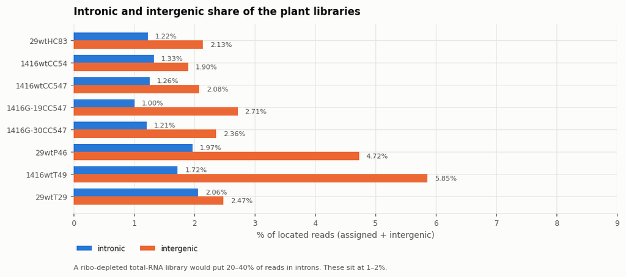

| sample | host | intronic_pct | intergenic_pct |
| --- | --- | --- | --- |
| 29wtHC83 | citrus_sinensis | 1.22 | 2.13 |
| 1416wtCC54 | citrus_sinensis | 1.33 | 1.90 |
| 1416wtCC547 | citrus_sinensis | 1.26 | 2.08 |
| 1416G-19CC547 | citrus_sinensis | 1.00 | 2.71 |
| 1416G-30CC547 | citrus_sinensis | 1.21 | 2.36 |
| 29wtP46 | carica_papaya | 1.97 | 4.72 |
| 1416wtT49 | solanum_lycopersicum | 1.72 | 5.85 |
| 29wtT29 | solanum_lycopersicum | 2.06 | 2.47 |

```python
intr = pd.read_csv(ROOT / "logs/intron_fraction.tsv", sep="\t").set_index("sample")
intr = intr.reindex([s for s in meta.index if s in intr.index])
intr["intronic_pct"] = 100 * intr.intronic / intr.located
intr["intergenic_pct"] = 100 * intr.intergenic / intr.located

fig, ax = plt.subplots(figsize=(9.5, 4.4))
y = np.arange(len(intr)); h = 0.36
ax.barh(y - h / 2, intr["intronic_pct"], height=h, color=SERIES[0], label="intronic")
ax.barh(y + h / 2, intr["intergenic_pct"], height=h, color=SERIES[1], label="intergenic")
for yi, (a, b) in enumerate(zip(intr["intronic_pct"], intr["intergenic_pct"])):
    ax.text(a + 0.12, yi - h / 2, f"{a:.2f}%", va="center", fontsize=7.5, color=INK2)
    ax.text(b + 0.12, yi + h / 2, f"{b:.2f}%", va="center", fontsize=7.5, color=INK2)
ax.set_yticks(y, intr.index); ax.invert_yaxis()
ax.set_xlim(0, 9)
ax.set_xlabel("% of located reads (assigned + intergenic)")
ax.set_title("Intronic and intergenic share of the plant libraries")
clean(ax, "x")
ax.legend(loc="upper left", bbox_to_anchor=(0, -0.15), ncols=2, borderaxespad=0)
note(ax, "A ribo-depleted total-RNA library would put 20–40% of reads in introns. These sit at 1–2%.",
     y=-0.27)
plt.tight_layout(); save(fig, "29_intron_fraction"); plt.show()

intr[["host", "intronic_pct", "intergenic_pct"]].round(2)
```

### What that means

Two independent measurements agree:

- **Gene class** — rRNA is 0.3–3 % of counted reads, protein-coding is 95–98 %, and the non-polyadenylated small RNAs (snoRNA, snRNA, miRNA) are flat zero.
- **Read position** — introns hold 1.0–2.1 % of located reads, an order of magnitude below what a ribo-depleted total-RNA library gives.

Both point one way: these are **polyA-selected** libraries. That is not the protocol written down in the repo.

The consequence runs through everything in the results notebook. Bacterial mRNA is **not polyadenylated**, so a polyA selection removes it by design. What survives on the *Agrobacterium* reference is the T-DNA: those genes sit in the plant genome after transfer, are transcribed by plant RNA polymerase II, and are polyadenylated like any other plant message — so they pass the selection while the bacterium's own chromosome does not.

It also changes the recommendation. The bacterial transcriptome here is not under-sequenced, it is **selected against** — more depth on these libraries would return more plant mRNA and proportionally as little bacterium. Recovering it needs a different preparation: rRNA depletion without polyA capture, ideally with bacterial enrichment, as the 2019 protocol in the repo actually describes.

### This is inference, not a kit name

Worth being exact about the standing of this claim, because a strong conclusion now rests on it. **No record of the library preparation exists in the project.** Not in the repo, not in `README.md`, and not in the vendor's own report: `30-1348328766/Azenta_30-1348328766_Data_Report.html` gives customer, quote number and an `Illumina 2x150bp` configuration, and its **Sample Type field is empty**. There is no kit, prep or selection field anywhere in it.

So the polyA reading is an inference from two independent properties of the reads, and it should be labelled that way in any write-up. Settling it documentarily means the Azenta order behind quote `30-1348328766`, or asking the submitting lab.

A third line of evidence is available and cheap: **strandedness**. The counts were produced with `STRAND=0` because strandedness was never confirmed, and a TruSeq Stranded library would show a clear antisense asymmetry. Testing it would both corroborate the prep and settle whether the matrices should be rebuilt with `-s 2` — an open question flagged in the Makefile header.

## 7. A spliced aligner over a bacterial genome

HISAT2 is built for eukaryotic transcriptomes: its purpose is to place reads across introns. Bacterial transcripts have none, so on the bacterial contigs that ability can only produce false joins. The pipeline runs

```
hisat2 -p $(THREADS) --dta -x references/combined/<strain>__<host> ...
```

with splicing enabled and no `--no-spliced-alignment`, and because a *combined* index means one set of flags for both organisms, the bacterium cannot be treated differently from the host without giving up the single competitive pass.

`scripts/splice_rates.sh` measures what that costs: how many alignments carry an `N` (skipped region) in their CIGAR, per organism.

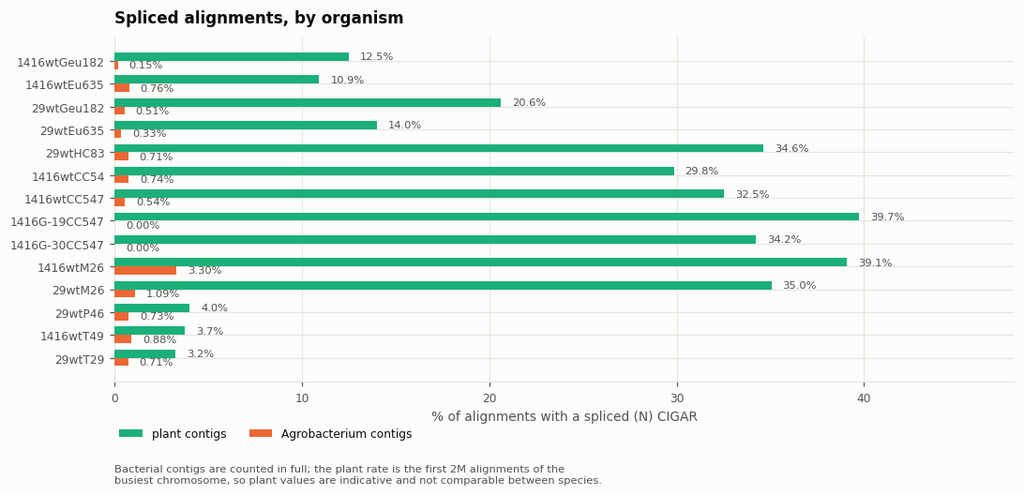

| sample | agro_alignments | agro_spliced | agro_pct | plant_pct |
| --- | --- | --- | --- | --- |
| 1416wtGeu182 | 22160 | 34 | 0.15 | 12.48 |
| 1416wtEu635 | 62014 | 471 | 0.76 | 10.91 |
| 29wtGeu182 | 88040 | 448 | 0.51 | 20.62 |
| 29wtEu635 | 34113 | 114 | 0.33 | 13.99 |
| 29wtHC83 | 39858 | 283 | 0.71 | 34.60 |
| 1416wtCC54 | 75597 | 558 | 0.74 | 29.84 |
| 1416wtCC547 | 44978 | 242 | 0.54 | 32.52 |
| 1416G-19CC547 | 158 | 0 | 0.00 | 39.71 |
| 1416G-30CC547 | 702 | 0 | 0.00 | 34.24 |
| 1416wtM26 | 164689 | 5432 | 3.30 | 39.10 |
| 29wtM26 | 195704 | 2128 | 1.09 | 35.04 |
| 29wtP46 | 163849 | 1202 | 0.73 | 4.00 |
| 1416wtT49 | 94402 | 831 | 0.88 | 3.73 |
| 29wtT29 | 85910 | 607 | 0.71 | 3.23 |

```python
sr = pd.read_csv(ROOT / "logs/splice_rates.tsv", sep="\t").set_index("sample")
sr = sr.reindex([s for s in meta.index if s in sr.index])
sr["agro_pct"] = 100 * sr.agro_spliced / sr.agro_alignments
sr["plant_pct"] = 100 * sr.plant_spliced / sr.plant_alignments

fig, ax = plt.subplots(figsize=(10, 5))
y = np.arange(len(sr)); h = 0.36
ax.barh(y - h / 2, sr["plant_pct"], height=h, color=PLANT, label="plant contigs")
ax.barh(y + h / 2, sr["agro_pct"], height=h, color=AGRO, label="Agrobacterium contigs")
for yi, (p, a) in enumerate(zip(sr["plant_pct"], sr["agro_pct"])):
    ax.text(p + 0.6, yi - h / 2, f"{p:.1f}%", va="center", fontsize=7.5, color=INK2)
    ax.text(a + 0.6, yi + h / 2, f"{a:.2f}%", va="center", fontsize=7.5, color=INK2)
ax.set_yticks(y, sr.index); ax.invert_yaxis()
ax.set_xlim(0, 48); ax.set_xlabel("% of alignments with a spliced (N) CIGAR")
ax.set_title("Spliced alignments, by organism")
clean(ax, "x")
ax.legend(loc="upper left", bbox_to_anchor=(0, -0.12), ncols=2, borderaxespad=0)
note(ax, "Bacterial contigs are counted in full; the plant rate is the first 2M alignments of the\n"
         "busiest chromosome, so plant values are indicative and not comparable between species.",
     y=-0.24)
plt.tight_layout(); save(fig, "28_spliced_alignments"); plt.show()

sr[["agro_alignments", "agro_spliced", "agro_pct", "plant_pct"]].round(2)
```

Splicing is doing real work on the plant side — 3 % to 40 % of alignments, depending on the species and the chromosome sampled — so it cannot simply be switched off. On the bacterial side it fires on **0 % to 3.3 %** of alignments, which is noise rather than nothing: a spuriously spliced read spanning two genes lands in featureCounts' ambiguous bin rather than on either gene.

At that rate it cannot manufacture the T-DNA result, where single genes carry 43–66 % of a sample's bacterial counts. If the bacterial side ever carries real signal, the cheap fix is to drop `N`-CIGAR alignments on `agro_*` contigs before counting — it needs no re-alignment and keeps the competitive assignment that the combined index exists to provide.

## In one paragraph

Fourteen unreplicated galls, each one strain on one host, are aligned against a reference built for that pairing: the strain's five replicons concatenated with the host assembly into a single HISAT2 index, bacterial contigs prefixed `agro_`. One alignment pass per sample assigns every read to its better match, and the prefix splits the result afterwards — `idxstats` for the read-level partition, `featureCounts` for per-gene matrices. Three host references carry gene models and produce matrices; the other three produce alignments only. The plant side is 50–160× the bacterial side by sequence, but the decisive factor is upstream of all of it: the read composition says these are polyA-selected libraries, which excludes bacterial mRNA by design and leaves only the plant-transcribed T-DNA behind on the bacterial reference.